## Course: COMPUTATIONAL THINKING FOR GOVERNANCE ANALYTICS

### Prof. José Manuel Magallanes, PhD

- Visiting Professor of Computational Policy at Evans School of Public Policy and Governance, and eScience Institute Senior Data Science Fellow, University of Washington.
- Professor of Government and Political Methodology, Pontificia Universidad Católica del Perú.

# R for Clustering

Collect the data we prepared in Python:

```r
link='https://github.com/EvansUW-GovAnalytics-Project/students_merge/raw/main/demohdikw.RDS'
# a RDS file from the web needs:
myFile=url(link)

# reading in data:
fromPy=readRDS(file = myFile)

# reset indexes to R format:
row.names(fromPy)=NULL
```

## Preparing data:

For all cases, you need the DISTANCE MATRIX:

**a.** Explore variables you will used for clustering

```r
dfClus=fromPy[,c('HDI','Democracy','kwh_pop')]
summary(dfClus)
```

```
##       HDI           Democracy        kwh_pop
##  Min.   :0.3766   Min.   :1.080   Min.   :    0.0
##  1st Qu.:0.5805   1st Qu.:3.220   1st Qu.:  384.4
##  Median :0.7278   Median :5.705   Median : 1544.3
##  Mean   :0.7120   Mean   :5.354   Mean   : 3398.1
##  3rd Qu.:0.8412   3rd Qu.:7.130   3rd Qu.: 4608.8
##  Max.   :0.9537   Max.   :9.810   Max.   :49910.5
##  NA's   :1
```

**b.** Rescale units if needed into a new variable:

```r
dfClus=scale(dfClus)

summary(dfClus)
```

```
##       HDI            Democracy          kwh_pop
##  Min.   :-2.1378   Min.   :-1.8980   Min.   :-0.6348
##  1st Qu.:-0.8382   1st Qu.:-0.9477   1st Qu.:-0.5630
##  Median : 0.1007   Median : 0.1558   Median :-0.3463
##  Mean   : 0.0000   Mean   : 0.0000   Mean   : 0.0000
##  3rd Qu.: 0.8238   3rd Qu.: 0.7885   3rd Qu.: 0.2262
##  Max.   : 1.5406   Max.   : 1.9786   Max.   : 8.6893
##  NA's   :1
```

**c.** Rename subset indexes and Verify what your input is:

```r
row.names(dfClus)=fromPy$Country
head(dfClus)
```

```
##                  HDI Democracy   kwh_pop
## Norway      1.540616  1.978603 3.5086710
## Iceland     1.443640  1.783220 8.6892631
## Sweden      1.431872  1.734375 1.7955603
## New Zealand 1.331536  1.729934 0.8435633
## Canada      1.339346  1.725494 1.9362719
## Finland     1.358980  1.707731 2.1332675
```

**d.** Set random seed:

```r
set.seed(999) # this is for replicability of results
```

**e.** Decide distance method and compute distance matrix:

```r
library(cluster)
dfClus_D=cluster::daisy(x=dfClus)
```

## Partitioning technique

### 1. Apply function: you need to indicate the amount of clusters required.

```r
NumCluster=4
res.pam = pam(x=dfClus_D,
              k = NumCluster,
              cluster.only = F)
```

### 2. Clustering results.

**2.1** Add results to original data frame:

```r
fromPy$pam=as.factor(res.pam$clustering)
```

**2.2** Query data frame as needed:

Example 1:

```r
fromPy[fromPy$pam==1,'Country']
```

```
##  [1] "Norway"                 "Iceland"                "Sweden"
##  [4] "New Zealand"            "Canada"                 "Finland"
##  [7] "Denmark"                "Ireland"                "Australia"
## [10] "Netherlands"            "Switzerland"            "Luxembourg"
## [13] "Germany"                "Uruguay"                "United Kingdom"
## [16] "Chile"                  "Austria"                "Japan"
## [19] "Spain"                  "Korea (Republic of)"    "France"
## [22] "United States"          "Portugal"               "Estonia"
## [25] "Israel"                 "Italy"                  "Malta"
## [28] "Czechia"                "Cyprus"                 "Slovenia"
## [31] "Belgium"                "Greece"                 "Latvia"
## [34] "Trinidad and Tobago"    "Lithuania"              "Slovakia"
## [37] "Poland"                 "Singapore"              "Hong Kong, China (SAR)"
## [40] "Kuwait"
```

Example 2:

```r
fromPy[fromPy$Country=="Peru",'pam']
```

```
## [1] 2
## Levels: 1 2 3 4
```

**2.2** REPORT: Table of clusters

```r
table(fromPy$pam)
```

```
##
##  1  2  3  4
## 40 47 48 29
```

### 3. Evaluate Results.

**3.1** REPORT: Average silhouettes

```r
library(factoextra)
```

```
##   cluster size ave.sil.width
## 1       1   40          0.25
## 2       2   47          0.52
## 3       3   48          0.46
## 4       4   29          0.28
```

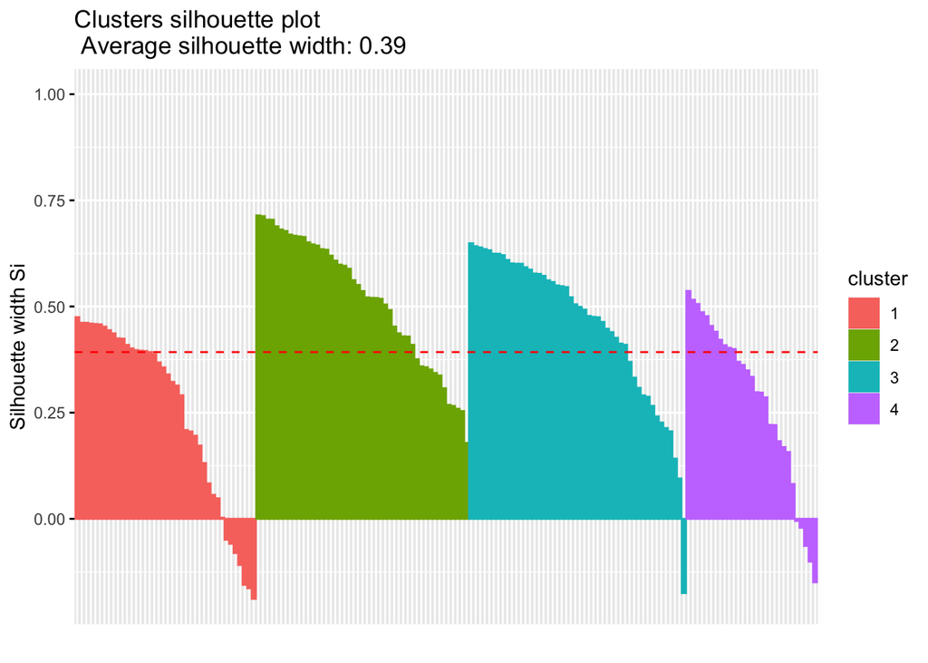

```r
fviz_silhouette(res.pam)
```

**3.2** REPORT: Detecting anomalies

1. Save individual silhouettes:

```r
pamEval=data.frame(res.pam$silinfo$widths)
head(pamEval)
```

```
##             cluster neighbor sil_width
## Australia         1        2 0.4748914
## Switzerland       1        2 0.4617337
## Japan             1        2 0.4616574
## Germany           1        2 0.4597413
## Luxembourg        1        2 0.4588899
## Austria           1        2 0.4579396
```

2. Request negative silhouettes: The ones that are poorly clustered.

```r
pamEval[pamEval$sil_width<0,]
```

```
##                                     cluster neighbor    sil_width
## Cyprus                                    1        2 -0.049299367
## Kuwait                                    1        4 -0.058726561
## Slovakia                                  1        2 -0.080700575
## Lithuania                                 1        2 -0.108733306
## Uruguay                                   1        2 -0.155512870
## Poland                                    1        2 -0.163459823
## Latvia                                    1        2 -0.188415934
## Honduras                                  3        2 -0.174847916
## Kyrgyzstan                                4        2 -0.004959795
## Korea (Democratic People's Rep. of)       4        3 -0.021038999
## Nicaragua                                 4        3 -0.063788920
## Turkey                                    4        2 -0.100791924
## Lao People's Democratic Republic          4        3 -0.149462716
```

## Hierarchizing: agglomerative

### 1. Apply function:

```r
library(factoextra)

res.agnes= hcut(dfClus_D,
                k = NumCluster,isdiss=T,
                hc_func='agnes',
                hc_method = "ward.D2")
```

### 2. Clustering results.

**2.1** Add results to original data frame:

```r
fromPy$agn=as.factor(res.agnes$cluster)
```

**2.2** Query data frame as needed:

Example 1:

```r
fromPy[fromPy$agn==1,'Country']
```

```
##  [1] "Norway"                 "Sweden"                 "New Zealand"
##  [4] "Canada"                 "Finland"                "Denmark"
##  [7] "Ireland"                "Australia"              "Netherlands"
## [10] "Switzerland"            "Luxembourg"             "Germany"
## [13] "Uruguay"                "United Kingdom"         "Chile"
## [16] "Austria"                "Costa Rica"             "Mauritius"
## [19] "Japan"                  "Spain"                  "Korea (Republic of)"
## [22] "France"                 "United States"          "Portugal"
## [25] "Estonia"                "Israel"                 "Italy"
## [28] "Malta"                  "Czechia"                "Botswana"
## [31] "Cyprus"                 "Slovenia"               "Belgium"
## [34] "Greece"                 "Latvia"                 "Malaysia"
## [37] "Panama"                 "Trinidad and Tobago"    "Jamaica"
## [40] "Lithuania"              "South Africa"           "Colombia"
## [43] "Slovakia"               "Argentina"              "Brazil"
## [46] "Poland"                 "Suriname"               "Bulgaria"
## [49] "Tunisia"                "Philippines"            "Hungary"
## [52] "Peru"                   "Croatia"                "Mongolia"
## [55] "Romania"                "Dominican Republic"     "Indonesia"
## [58] "Serbia"                 "Paraguay"               "Sri Lanka"
## [61] "Ecuador"                "Albania"                "Mexico"
## [64] "Thailand"               "Singapore"              "Ukraine"
## [67] "Moldova (Republic of)"  "Montenegro"             "Fiji"
## [70] "Hong Kong, China (SAR)" "Armenia"                "Georgia"
```

Example 2:

```r
fromPy[fromPy$Country=="Peru",'agn']
```

```
## [1] 1
## Levels: 1 2 3 4
```

**2.2** REPORT: Table of clusters

Reporting results:

```r
table(fromPy$agn)
```

```
##
##  1  2  3  4
## 72  1 59 32
```

### 3. Evaluate Results.

**3.1a** REPORT: Dendogram

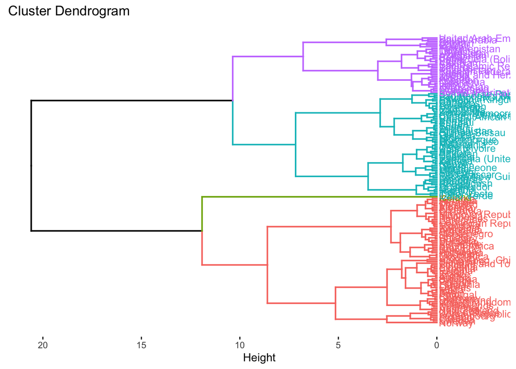

```r
fviz_dend(res.agnes,k=NumCluster, cex = 0.7, horiz = T)
```

**3.1b** REPORT: Average silhouettes:

```
##   cluster size ave.sil.width
## 1       1   72          0.45
## 2       2    1          0.00
## 3       3   59          0.41
## 4       4   32          0.27
```

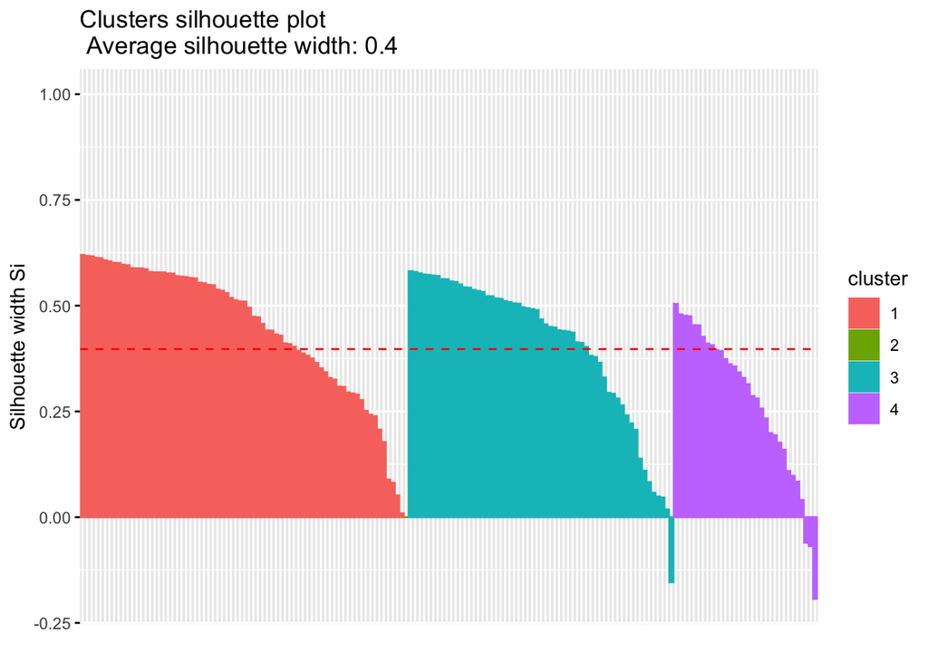

```r
library(factoextra)
fviz_silhouette(res.agnes)
```

**3.2** REPORT: Detecting anomalies

1. Saving silhouettes:

```r
agnEval=data.frame(res.agnes$silinfo$widths)
head(agnEval)
```

```
##          cluster neighbor sil_width
## Portugal       1        4 0.6200552
## Spain          1        4 0.6176005
## Italy          1        4 0.6166958
## Malta          1        4 0.6133081
## Chile          1        4 0.6121720
## Czechia        1        4 0.6073515
```

2. Requesting negative silhouettes:

```r
agnEval[agnEval$sil_width<0,]
```

```
##            cluster neighbor   sil_width
## Cabo Verde       3        1 -0.15381127
## Nicaragua        4        3 -0.06054771
## Morocco          4        3 -0.06844242
## Guatemala        4        3 -0.19303413
```

## Hierarchizing: divisive

### 1. Apply function: you need to indicate the amount of clusters required.

```r
library(factoextra)

res.diana= hcut(dfClus_D, k = NumCluster,
                 hc_func='diana',
                 hc_method = "ward.D")
```

### 2. Clustering results.

**2.1** Add results to original data frame:

```r
fromPy$dia=as.factor(res.diana$cluster)
```

**2.2** Query data frame as needed:

Example 1:

```r
fromPy[fromPy$dia==1,'Country']
```

```
##  [1] "Norway"                 "Sweden"                 "New Zealand"
##  [4] "Canada"                 "Finland"                "Denmark"
##  [7] "Ireland"                "Australia"              "Netherlands"
## [10] "Switzerland"            "Luxembourg"             "Germany"
## [13] "Uruguay"                "United Kingdom"         "Chile"
## [16] "Austria"                "Japan"                  "Spain"
## [19] "Korea (Republic of)"    "France"                 "United States"
## [22] "Portugal"               "Estonia"                "Israel"
## [25] "Italy"                  "Malta"                  "Czechia"
## [28] "Cyprus"                 "Slovenia"               "Belgium"
## [31] "Greece"                 "Latvia"                 "Trinidad and Tobago"
## [34] "Lithuania"              "Slovakia"               "Poland"
## [37] "Singapore"              "Hong Kong, China (SAR)" "Kuwait"
```

Example 2:

```r
fromPy[fromPy$Country=="Peru",'dia']
```

```
## [1] 3
## Levels: 1 2 3 4
```

**2.2** REPORT: Table of clusters

Reporting results:

```r
table(fromPy$dia)
```

```
##
##  1  2  3  4
## 39  1 43 81
```

### 3. Evaluate Results.

**3.1a** REPORT: Dendogram

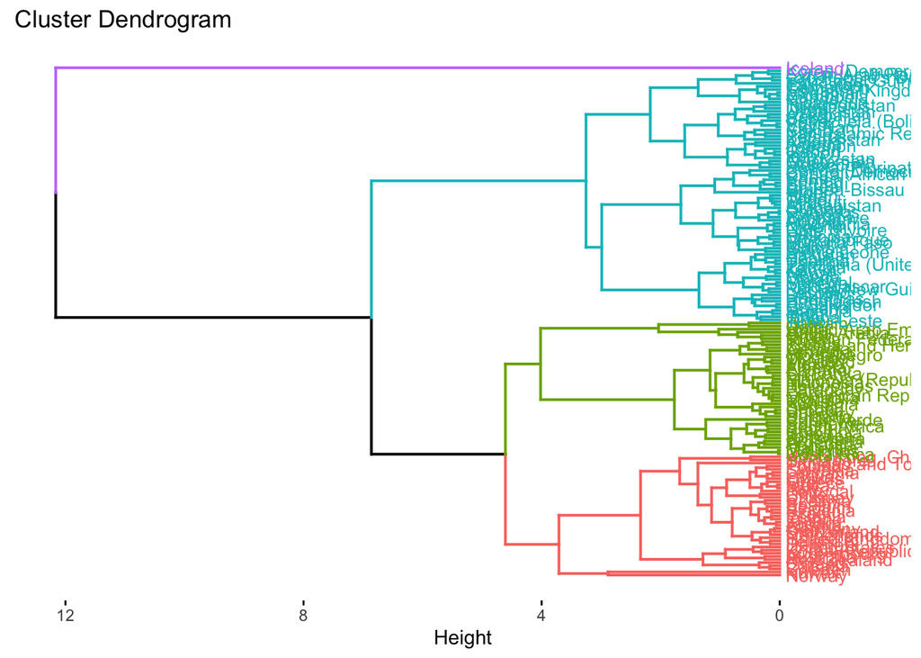

```r
fviz_dend(res.diana,k=NumCluster, cex = 0.7, horiz = T)
```

**3.1b** REPORT: Average silhouettes:

```
##   cluster size ave.sil.width
## 1       1   39          0.37
## 2       2    1          0.00
## 3       3   43          0.36
## 4       4   81          0.33
```

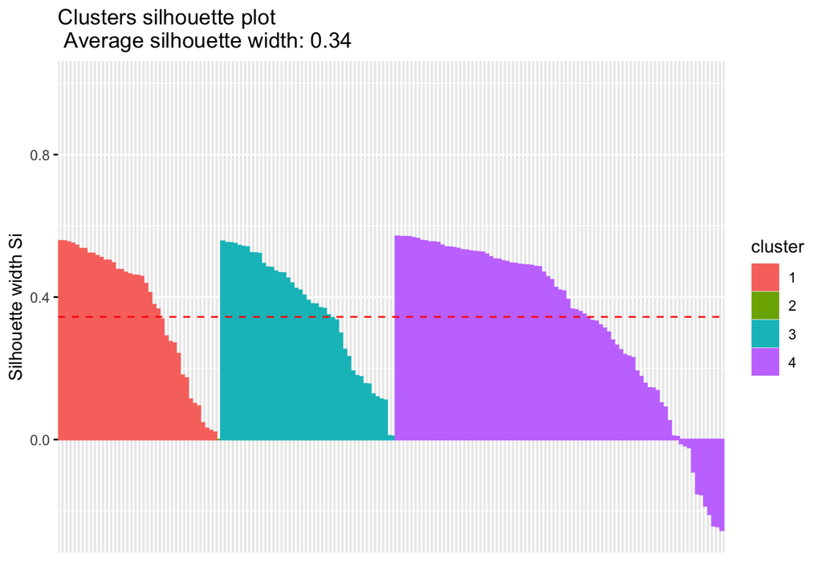

```r
library(factoextra)
fviz_silhouette(res.diana)
```

**3.2** REPORT: Detecting anomalies

1. Saving silhouettes:

```r
diaEval=data.frame(res.diana$silinfo$widths)
head(diaEval)
```

```
##             cluster neighbor sil_width
## Austria           1        3 0.5578750
## Japan             1        3 0.5571030
## Germany           1        3 0.5543251
## Switzerland       1        3 0.5505643
## Australia         1        3 0.5449229
## Netherlands       1        3 0.5357601
```

2. Requesting negative silhouettes:

```r
diaEval[diaEval$sil_width<0,]
```

```
##                                  cluster neighbor   sil_width
## Morocco                                4        3 -0.01108631
## Algeria                                4        3 -0.01694020
## Belarus                                4        3 -0.02233897
## Lebanon                                4        3 -0.09041656
## Bolivia (Plurinational State of)       4        3 -0.15175111
## Kazakhstan                             4        3 -0.15428651
## Timor-Leste                            4        3 -0.18613515
## El Salvador                            4        3 -0.20976608
## India                                  4        3 -0.24175090
## Namibia                                4        3 -0.24407989
## Guyana                                 4        3 -0.25446710
```

## Density-based clustering

You input the distance and the minimal number of neighbors that form a cluster.

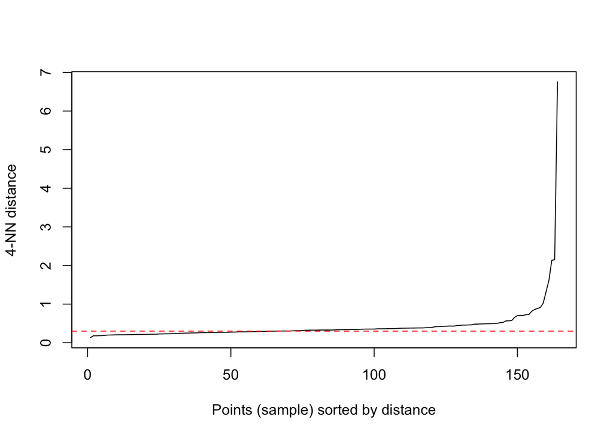

```r
library(dbscan)
#minNeighs>= num cols in data
minNeighs=4
kNNdistplot(dfClus_D, k = minNeighs)
abline(h=0.3, col = "red", lty=2)
```

```r
distance=0.3
res.db = dbscan::dbscan(dfClus_D,
                        eps=distance,
                        minPts=minNeighs)
```

**REPORT**:

How many cluster were produced? and How many outliers are there?

```r
# '0' identifies outliers:
res.db
```

```
## DBSCAN clustering for 164 objects.
## Parameters: eps = 0.3, minPts = 4
## The clustering contains 4 cluster(s) and 56 noise points.
##
##  0  1  2  3  4
## 56 58 15 27  8
##
## Available fields: cluster, eps, minPts
```

Save result:

```r
fromPy$db=as.factor(res.db$cluster)
```

# How to compare clustering?

- Prepare a bidimensional map:

```r
projectedData = cmdscale(dfClus_D, k=2)
#
# save coordinates to original data frame:
fromPy$dim1 = projectedData[,1]
fromPy$dim2 = projectedData[,2]
```

- See the “map”:

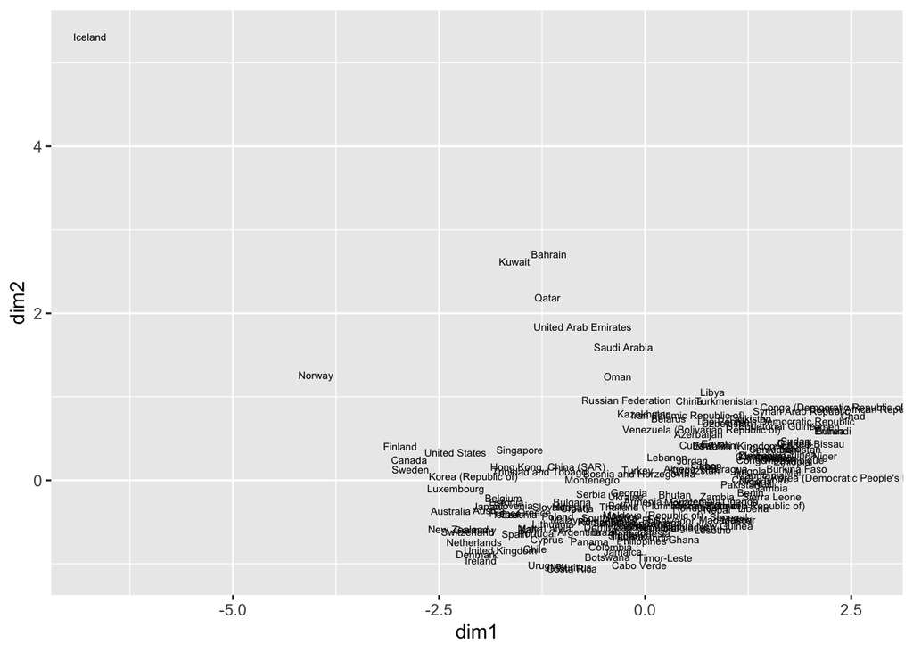

```r
base= ggplot(data=fromPy,
             aes(x=dim1, y=dim2,
                 label=Country))
base + geom_text(size=2)
```

- Plot results from PAM:

```r
pamPlot=base + labs(title = "PAM") + geom_point(size=2,
                                              aes(color=pam),
                                              show.legend = F)
```

- Plot results from Hierarchical AGNES:

```r
agnPlot=base + labs(title = "AGNES") + geom_point(size=2,
                                              aes(color=agn),
                                              show.legend = F)
```

- Plot results from Hierarchical DIANA:

```r
diaPlot=base + labs(title = "DIANA") + geom_point(size=2,
                                              aes(color=dia),
                                              show.legend = F)
```

Compare visually:

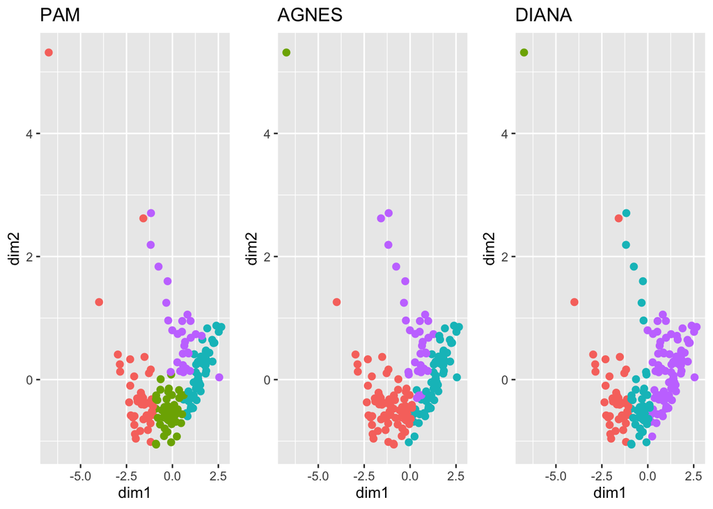

```r
library(ggpubr)
ggarrange(pamPlot, agnPlot, diaPlot,ncol = 3)
```

- Plot results from DBSCAN:

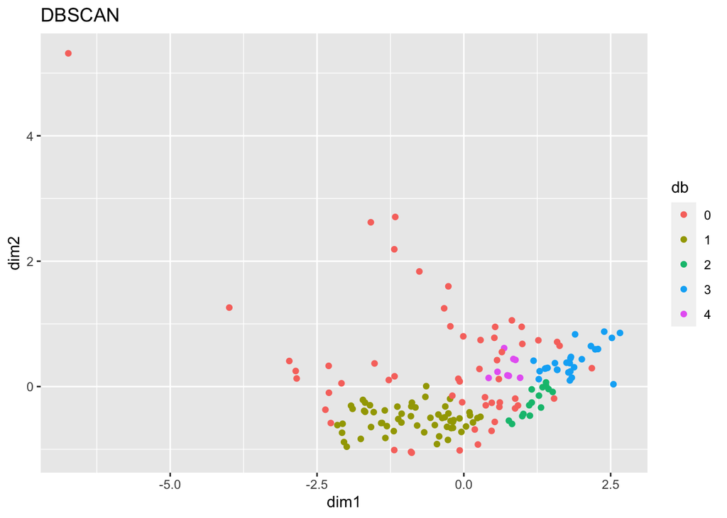

```r
dbPlot= base + labs(title = "DBSCAN") + geom_point(aes(color=db),
                                               show.legend = T)
dbPlot
```

Annotating:

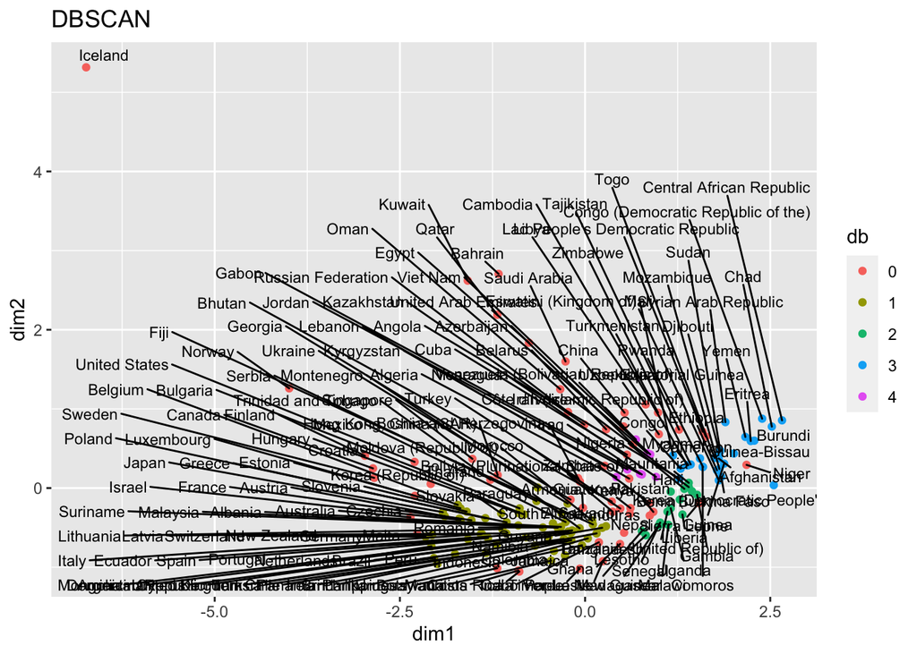

```r
library(ggrepel)
dbPlot + geom_text_repel(size=3,aes(label=Country))
```

Annotating outliers:

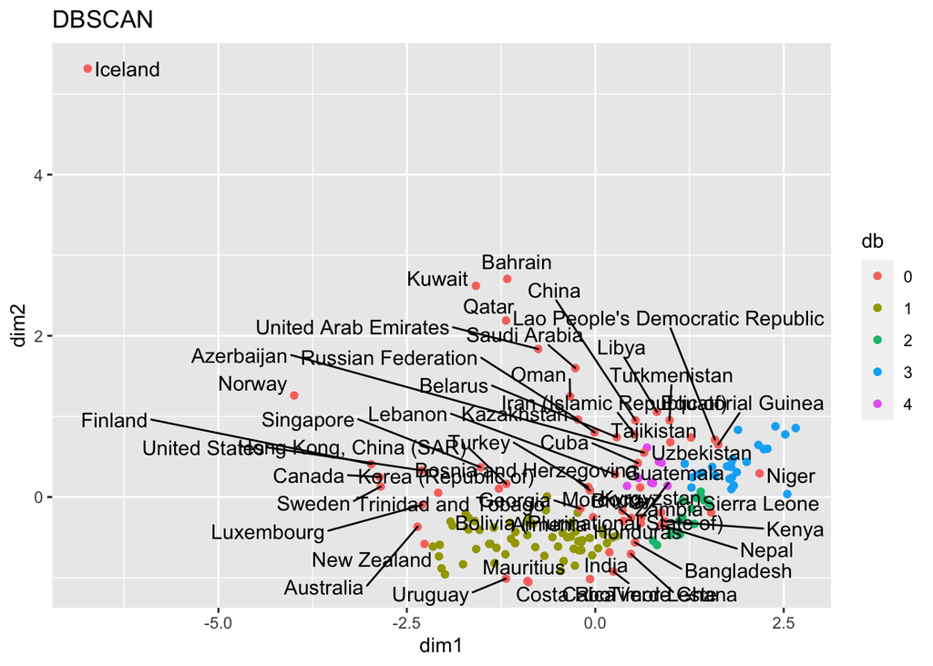

```r
LABEL=ifelse(fromPy$db==0,fromPy$Country,"")

dbPlot + geom_text_repel(aes(label=LABEL))
```